# Quick Start Guide for a modelling framework to improve antibody titer estimation from dilution series data

## Introduction

This quick-start guide provides basic instructions for using a Bayesian hierarchical modelling framework to estimate antibody titers while correcting for batch effects and other sources of experimental variation.

We use simulated dilution series data, mirroring the structure of data from respiratory syncytial virus (RSV) foci reduction neutralization tests (FRNTs), as an application example. Four levels of working virus dilution (an assay-level covariate) are simulated, with seven batches per level and 20 samples per batch, yielding a total of 28 batches and 560 serum samples. Each batch includes a virus control (VC), a positive control (PC), and an International Standard control (IS), which is assumed to be tested at two different concentrations (denoted as IS1 and IS2). The VC is assumed to be prepared at fixed dilutions with 22 replicates per batch. Each serum sample, along with the PC and IS, is assumed to be tested in duplicate across 3-fold serial dilutions ranging from 1:40 to 1:87480.

## Outline

The following steps are covered in this guide:

1. Getting started
2. Formating and inputting dilution series data
3. Estimating assay-level fixed effects
4. Generating foci reduction data
5. Removing ‘Clear negative’ samples
6. Running MCMC to generat batch-adjusted antibody titers
7. Processing outputs and generating plots

## 1. Getting started

we first load the required R libraries and the Stan model code. We use two hierarchical models in this workflow:

- **Model 1:** Estimates assay-level fixed effects, such as the effect of different virus working dilutions.
- **Model 2:** Estimates antibody titers for each serum sample while correcting for batch effects.

```r
# Clear workspace
rm(list = ls())

# Load required libraries
library(readxl)
library(dplyr)
library(ggplot2)
library(rstan)
library(bayesplot)

# Load Stan model code
source("Stan_Model.R")

# Set seed
set.seed(12345)
```

## 2. Formating and inputting dilution series data

The modelling framework expects dilution series data for all samples to be provided in long format, with the following columns:

1. sto_id: Index for each level of virus working dilution (or any other assay-level fixed effect that varies across batches).
2. bat_id: Index for each experimental batch.
3. sam_id: Index for each sample.
4. rep_id: Index for the replicate number for each sample.
5. dilution: Reciprocal of the dilution factor.
6. Count: Count of foci.

Similarly, experimental data for the PC, IS, and VC should also be provided in long format. The PC and IS datasets should include the columns sto_id, bat_id, rep_id, dilution, and Count, while the VC dataset should include sto_id, bat_id, and Count.

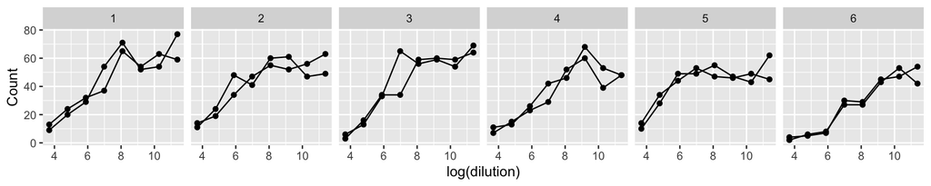

```r
# Input experimental data from excel ----
df_sam <- read_excel("simu_data.xlsx", sheet = "Sample")
df_PC <- read_excel("simu_data.xlsx", sheet = "PC")
df_IS1 <- read_excel("simu_data.xlsx", sheet = "IS500")
df_IS2 <- read_excel("simu_data.xlsx", sheet = "IS1000")
df_VC <- read_excel("simu_data.xlsx", sheet = "VC")

# Check experimental data
df_sam %>% filter(sam_id %in% 1:6) %>%
  ggplot(aes(x = log(dilution), y = Count)) +
  geom_point() +
  geom_line(aes(group = rep_id)) +
  facet_wrap(~ sam_id, nrow = 1)
```

## 3. Estimating assay-level fixed effects

Assay-level fixed effects are estimated using Model 1. In this example, assay-level fixed effects represent the mean foci counts for each virus working dilution in the VC. This information will later be used to calculate foci reduction data.

The model expects input as a list with the following components:

1. num_sto_vc: Number of virus working dilution levels.
2. num_bat_vc: Number of experimental batches.
3. num_obs_vc: Total number of observations (including all VC replicates).
4. which_sto_vc: Index of the virus working dilution for each observation.
5. which_bat_vc: Index of the batch for each observation.
6. count_vc: Foci count for each observation.
7. which_sto_per_bat: Index mapping virus working dilution to each batch.
8. delta_prior: Prior distribution parameter for assay-level fixed effects.
9. sample_from_prior: Indicator for sampling from the prior only (0 = no, 1 = yes).

```r
# Mapping sto_id to batches
which_sto_per_bat <- df_VC %>% group_by(bat_id) %>% slice(1)

# Prepare data list for Stan model
data1_stan <- list(num_sto_vc = 4,
                   num_bat_vc = 28,
                   num_obs_vc = nrow(df_VC),
                   which_sto_vc = df_VC$sto_id,
                   which_bat_vc = df_VC$bat_id,
                   count_vc = df_VC$Count,

                   which_sto_per_bat = which_sto_per_bat$sto_id,
                   # Priors
                   delta_prior = c(48, 44, 40, 25),
                   sample_from_prior = 0)

# Compile the Stan model
model <- stan_model(model_code=model1_code)
# Fit the model using MCMC
# This step takes approximately 2 minutes.
# If no progress is observed, please try setting cores = 1.
fit1 <- stan(model_code=model1_code, data=data1_stan,
             chains=4, cores=4, iter=3000,
             control = list(adapt_delta = 0.95))
# Save the fitted model for future use
saveRDS(fit1, file = "Simu_fit1.rds")
# Extract posterior samples from the fitted model
posterior1 <- extract(fit1)
# Summarize assay-level effects (median across posterior samples)
sto_param <- data.frame(
  sto_id = 1:4,
  post_sto_effect = apply(posterior1$delta, 2, median)
)
```

## 4. Generating foci reduction data

We account for assay-level fixed effects by calculating foci reduction, defined here as the proportion of foci reduction at each dilution relative to the mean foci count of VC for the same virus working dilution, as estimated by Model 1.

```r
df_PC <- left_join(df_PC, sto_param)
df_PC$FR <- 1 - df_PC$Count/df_PC$post_sto_effect

df_IS1 <- left_join(df_IS1, sto_param)
df_IS1$FR <- 1 - df_IS1$Count/df_IS1$post_sto_effect

df_IS2 <- left_join(df_IS2, sto_param)
df_IS2$FR <- 1 - df_IS2$Count/df_IS2$post_sto_effect

df_sam <- left_join(df_sam, sto_param)
df_sam$FR <- 1 - df_sam$Count/df_sam$post_sto_effect
```

## 5. Removing ‘Clear negative’ samples

“Clear negative” samples, defined as those exhibiting less than 30% foci reduction at the starting dilution (allowing a 20% margin to account for potential measurement error due to intra- or inter-batch variation), were excluded from curve fitting. This is reasonable because foci reduction decreases monotonically with dilution, indicating that the true response curves for such samples are highly unlikely to reach the 50% foci reduction threshold.

```r
sample_fitting <- df_sam %>% filter(dilution == 40) %>%
  group_by(sam_id, bat_id) %>%
  summarise(max_y = mean(FR)) %>%
  filter(max_y > 0.3) %>%
  arrange(sam_id)
clear_neg <- df_sam %>% filter(!sam_id %in% sample_fitting$sam_id)
clear_neg <- unique(clear_neg$sam_id)

# Assign new sample IDs after removing 'Clear negative' samples
# New IDs should be continuous and start from 1
sample_fitting$sam_id_new <- 1:nrow(sample_fitting)
# Keep only samples retained for curve fitting
df_sam <- df_sam %>% filter(sam_id %in% sample_fitting$sam_id)
# Join new sample IDs back to the main dataset
df_sam <- left_join(df_sam, sample_fitting[, c("sam_id", "sam_id_new")],
                    by = join_by(sam_id))
```

## 6. Running MCMC to generat batch-adjusted antibody titers

Sample-specific antibody titers are estimated using Model 2, with random batch effects being corrected. Depending on the experiment-specific assay design and sources of variability, this batch-effect correction framework can also be applied to adjust for other laboratory- or experiment-level random effects, such as heterogeneity arising from differences in assay protocols, equipment, reagents, or personnel, which are common in large-scale or multicenter studies.

The model expects input as a list with the following components:

1. num_bat_total: Total number of batches
2. Foci reduction data from assay controls.  
   The same set of inputs is required for each serially diluted assay control; in this example, this includes PC, IS1, and IS2.  
   **Note**: If the experimental design does not include the International Standard, you need to remove all IS-related parts from the Stan model code before running the code.
   - num_obs_pc: Total number of PC observations.
   - which_bat_pc: Index of the batch corresponding to each PC observation.
   - x_log_pc: Log-transformed reciprocal dilution.
   - y_pc: Proportion of foci reduction.
3. Foci reduction data from serum samples
   - num_sam：Total number of serum samples.
   - num_obs：Total number of observations for all samples.
   - which_bat：Index of the batch corresponding to each observation.
   - which_sam：Index of the sample corresponding to each observation.
   - x_log：Log-transformed reciprocal dilution.
   - y：Proportion of foci reduction.
   - which_bat_per_sam: Index of the batch for each sample.
4. Priors
   - f_pc_prior：Prior 4PL parameters for PC.
   - f_IS1_prior：Prior 4PL parameters for IS1.
   - f_IS2_prior：Prior 4PL parameters for IS2.
   - f_pop_prior：Prior population-level 4PL parameters.
5. Lower and upper bounds for each 4PL parameters
   - f_lower: Lower bounds.
   - f_upper: Upper bounds.
6. sample_from_prior: Indicator for sampling from the prior only (0 = no, 1 = yes).

```r
# Prepare data list for Stan model
data2_stan <- list(num_bat_total = 28,

                   num_obs_pc = nrow(df_PC),
                   which_bat_pc = df_PC$bat_id,
                   x_log_pc = log(df_PC$dilution),
                   y_pc = df_PC$FR,

                   num_obs_IS1 = nrow(df_IS1),
                   which_bat_IS1 = df_IS1$bat_id,
                   x_log_IS1 = log(df_IS1$dilution),
                   y_IS1 = df_IS1$FR,

                   num_obs_IS2 = nrow(df_IS2),
                   which_bat_IS2 = df_IS2$bat_id,
                   x_log_IS2 = log(df_IS2$dilution),
                   y_IS2 = df_IS2$FR,

                   num_sam = length(unique(df_sam$sam_id_new)),
                   num_obs = nrow(df_sam),
                   which_bat = df_sam$bat_id,
                   which_sam = df_sam$sam_id_new,
                   x_log = log(df_sam$dilution),
                   y = df_sam$FR,

                   which_bat_per_sam = sample_fitting$bat_id,

                   f_pc_prior = c(1, 0, 1, 6),
                   f_IS1_prior = c(1, 0, 1, 6),
                   f_IS2_prior = c(1, 0, 1, 6),
                   f_pop_prior = c(1, 0, 1, 6),

                   f_lower = c(0, -1, 0, log(40)),
                   f_upper = c(2,  1, 1, log(87480)),

                   sample_from_prior = 0)

# Compile the Stan model
model <- stan_model(model_code=model2_code)
# Fit the model using MCMC
# This step takes approximately 15–30 minutes for this example.
fit2 <- stan(model_code=model2_code, data=data2_stan,
             chains=4, cores=4, iter=3000,
             control = list(adapt_delta = 0.95))
# Save the fitted model for future use
saveRDS(fit2, file = "Simu_fit2.rds")
# Extract posterior samples from the fitted model
posterior2 <- extract(fit2)
```

## 7. Processing outputs and generating plots

### 7.1 Model diagnosis

After fitting the model, it is important to assess MCMC convergence (i.e., number of divergent transitions, Rhat values, and trace plots for model parameters) before proceeding with downstream titer estimates, thereby ensuring the reliability of the MCMC results.

```r
# Number of divergence transitions
sampler_params <- get_sampler_params(fit2, inc_warmup = FALSE)
divergent_per_chain <- sapply(sampler_params, function(x) sum(x[,"divergent__"]))
divergent_per_chain
```

```
## [1] 0 0 0 0
```

```r
# Rhat
fit_summary <- summary(fit2)$summary
summary(fit_summary[, "Rhat"])
```

```
##    Min. 1st Qu.  Median    Mean 3rd Qu.    Max.
##  0.9994  0.9996  0.9998  0.9999  1.0000  1.0108
```

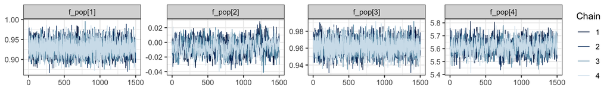

```r
# Check population-level parameters
f_pop_samples <- rstan::extract(fit2, pars = c("f_pop[1]", "f_pop[2]", "f_pop[3]",  "f_pop[4]"), permuted = FALSE)
mcmc_trace(f_pop_samples, facet_args = list(nrow = 1)) +
  theme_bw()
```

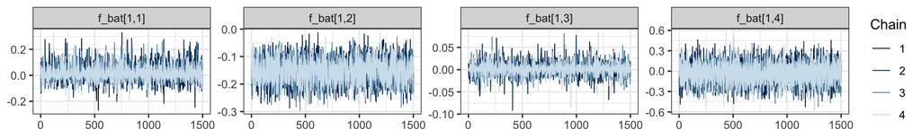

```r
# Check batch-level parameters
pars_to_check <- c("f_bat[1,1]", "f_bat[1,2]", "f_bat[1,3]", "f_bat[1,4]")
f_bat_samples <- rstan::extract(fit2, pars = pars_to_check, permuted = FALSE)
mcmc_trace(f_bat_samples, facet_args = list(nrow = 1)) +
  theme_bw()
```

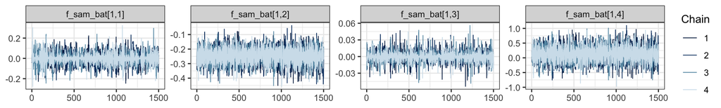

```r
# Check sample-level parameters
pars_to_check <- c("f_sam_bat[1,1]", "f_sam_bat[1,2]", "f_sam_bat[1,3]", "f_sam_bat[1,4]")
f_sam_samples <- rstan::extract(fit2, pars = pars_to_check, permuted = FALSE)
mcmc_trace(f_sam_samples, facet_args = list(nrow = 1)) +
  theme_bw()
```

### 7.2 4PL curve fits for PC and IS

By comparing batch-specific fitted curves with the BHM-adjusted overall curves for PC and IS, batch-to-batch variability can be visually assessed.

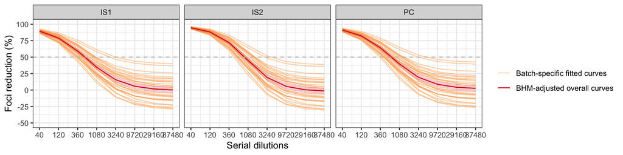

```r
# Batch-specific fitted curves
df_PC$BHM_fit_FR <- apply(posterior2$mu_y_pc, 2, median)
df_IS1$BHM_fit_FR <- apply(posterior2$mu_y_IS1, 2, median)
df_IS2$BHM_fit_FR <- apply(posterior2$mu_y_IS2, 2, median)
df_PC$control_sample <- "PC"
df_IS1$control_sample <- "IS1"
df_IS2$control_sample <- "IS2"
df_control <- rbind(df_PC, df_IS1, df_IS2)
df_control$curve_type <- "Batch-specific fitted curves"

# BHM-adjusted overall curves
Adj_PC_curve <- data.frame(control_sample = "PC",
                           dilution =  unique(df_PC$dilution),
                           BHM_fit_FR = apply(posterior2$y_pc_adj, 2, median),
                           BHM_fit_FR_lower = apply(posterior2$y_pc_adj, 2, quantile, 0.025),
                           BHM_fit_FR_upper = apply(posterior2$y_pc_adj, 2, quantile, 0.975))
Adj_IS1_curve <- data.frame(control_sample = "IS1",
                            dilution =  unique(df_IS1$dilution),
                            BHM_fit_FR = apply(posterior2$y_IS1_adj, 2, median),
                            BHM_fit_FR_lower = apply(posterior2$y_IS1_adj, 2, quantile, 0.025),
                            BHM_fit_FR_upper = apply(posterior2$y_IS1_adj, 2, quantile, 0.975))
Adj_IS2_curve <- data.frame(control_sample = "IS2",
                            dilution =  unique(df_IS2$dilution),
                            BHM_fit_FR = apply(posterior2$y_IS2_adj, 2, median),
                            BHM_fit_FR_lower = apply(posterior2$y_IS2_adj, 2, quantile, 0.025),
                            BHM_fit_FR_upper = apply(posterior2$y_IS2_adj, 2, quantile, 0.975))
df_control_adj <- rbind(Adj_PC_curve, Adj_IS1_curve, Adj_IS2_curve)
df_control_adj$curve_type <- "BHM-adjusted overall curves"

# Plot batch-specific fitted curves and BHM-adjusted overall curves
ggplot() +
  geom_line(data = df_control,
            aes(x = log(dilution),
                y = BHM_fit_FR,
                group = bat_id,
                color = curve_type), alpha = 0.5) +
  geom_line(data = df_control_adj,
            aes(x = log(dilution),
                y = BHM_fit_FR,
                color = curve_type)) +
  geom_ribbon(data = df_control_adj,
              aes(x = log(dilution),
                  ymin = BHM_fit_FR_lower,
                  ymax = BHM_fit_FR_upper),
              fill = "#D7191C", alpha = 0.2) +
  geom_hline(yintercept = 0.5, color = "grey", linetype = "dashed") +
  facet_wrap(~factor(control_sample)) +
  scale_color_manual("",
                     values = c("Batch-specific fitted curves" = "#FDAE61",
                                "BHM-adjusted overall curves" = "#D7191C")) +
  scale_x_continuous("Serial dilutions",
                     breaks = log(unique(df_control_adj$dilution)),
                     labels = unique(df_control$dilution)) +
  scale_y_continuous("Foci reduction (%)",
                      limits = c(-0.5, 1),
                      breaks = seq(-0.5, 1, 0.25),
                      labels = 100 * seq(-0.5, 1, 0.25)) +
  theme_bw()
```

### 7.3 4PL curve fits for a specific sample

By comparing BHM-adjusted and unadjusted 4PL curves, the impact of batch effects on the titer estimate for each sample can be visually assessed.

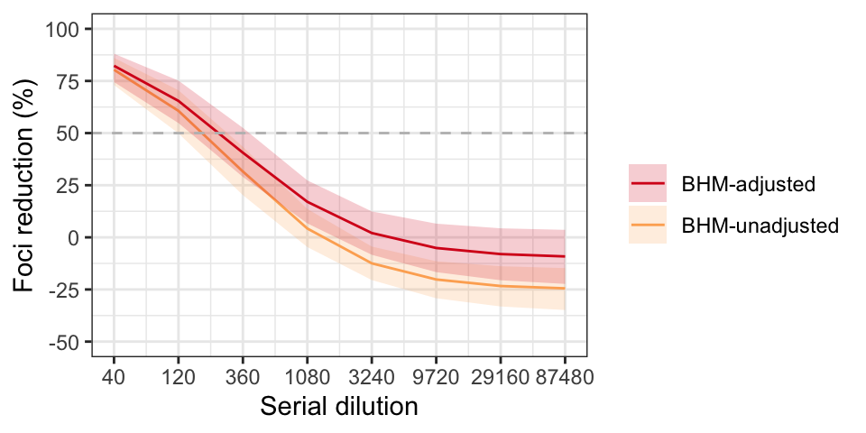

```r
sample_to_check <- 1
# BHM-unadjusted curve
df_sam$BHM_fit_FR <- apply(posterior2$mu_y, 2, median)
df_sam$BHM_fit_FR_lower <- apply(posterior2$mu_y, 2, quantile, 0.025)
df_sam$BHM_fit_FR_upper <- apply(posterior2$mu_y, 2, quantile, 0.975)
# BHM-adjusted curve
BHM_adj_FR <- apply(posterior2$y_sam_adj, c(2, 3), median)
BHM_adj_FR_lower <- apply(posterior2$y_sam_adj, c(2, 3), quantile, 0.025)
BHM_adj_FR_upper <- apply(posterior2$y_sam_adj, c(2, 3), quantile, 0.975)
# Plot BHM-adjusted and BHM-unadjusted curves
df_sam %>% filter(sam_id_new == sample_to_check) %>%
  ggplot() +
  geom_ribbon(aes(x = log(dilution),
                  ymin = BHM_fit_FR_lower,
                  ymax = BHM_fit_FR_upper,
                  fill = "BHM-unadjusted"),
               alpha = 0.2) +
  geom_line(aes(x = log(dilution),
                y = BHM_fit_FR,
                group = sam_id_new,
                color = "BHM-unadjusted")) +
  geom_line(data = data.frame(dilution = unique(df_sam$dilution),
                              BHM_adj_FR = BHM_adj_FR[, sample_to_check]),
            aes(x = log(dilution),
                y = BHM_adj_FR,
                color = "BHM-adjusted")) +
  geom_ribbon(data = data.frame(dilution = unique(df_sam$dilution),
                                BHM_adj_FR_lower = BHM_adj_FR_lower[, sample_to_check],
                                BHM_adj_FR_upper = BHM_adj_FR_upper[, sample_to_check]),
              aes(x = log(dilution),
                  ymin = BHM_adj_FR_lower,
                  ymax = BHM_adj_FR_upper,
                  fill = "BHM-adjusted"),
               alpha = 0.2) +
  geom_hline(yintercept = 0.5, color = "grey", linetype = "dashed") +
  scale_color_manual("",
                     values = c("BHM-unadjusted" = "#FDAE61",
                                "BHM-adjusted" = "#D7191C")) +
   scale_fill_manual("",
                     values = c("BHM-unadjusted" = "#FDAE61",
                                "BHM-adjusted" = "#D7191C")) +
  scale_x_continuous("Serial dilution",
                     breaks = log(unique(df_control_adj$dilution)),
                     labels = unique(df_control$dilution)) +
  scale_y_continuous("Foci reduction (%)",
                      limits = c(-0.5, 1),
                      breaks = seq(-0.5, 1, 0.25),
                      labels = 100 * seq(-0.5, 1, 0.25)) +
  theme_bw()
```

### 7.4 Estimating BHM-adjusted antibody titers

```r
# Summarize posterior samples: median and 95% CrI, log2-transformed
posterior_summary <- apply(posterior2$Nt_sam_adj, 2, function(x) {
  Median <- exp(median(x))
  CrI_lower <- exp(quantile(x, 0.025))
  CrI_upper <- exp(quantile(x, 0.975))
  c(log2(Median), log2(CrI_lower), log2(CrI_upper))
})

summary_df <- as.data.frame(t(posterior_summary))
colnames(summary_df) <- c("Estimate", "CrI_lower", "CrI_upper")
summary_df$sam_id_new <- 1:nrow(summary_df)


sample_fitting <- left_join(sample_fitting[, c("sam_id", "sam_id_new")],
                            summary_df, by = join_by(sam_id_new))

# Include'clear negative' samples
clear_neg_data <- data.frame(sam_id = clear_neg,
                             sam_id_new = NA,
                             Estimate = log2(40/3),
                             CrI_lower = NA,
                             CrI_upper = NA)
# Combine results and sort by sample ID
titer_estimate <- rbind(sample_fitting, clear_neg_data) %>%
  arrange(sam_id)
# Preview results
titer_estimate[1:10,]
```

```
## # A tibble: 10 × 5
## # Groups:   sam_id [10]
##    sam_id sam_id_new Estimate CrI_lower CrI_upper
##     <dbl>      <int>    <dbl>     <dbl>     <dbl>
##  1      1          1     7.92      7.22      8.64
##  2      2          2     7.55      6.80      8.29
##  3      3          3     8.15      7.49      8.79
##  4      4          4     8.91      8.09      9.70
##  5      5          5     6.91      6.10      7.73
##  6      6          6    11.0      10.2      11.9
##  7      7          7     7.12      6.26      7.99
##  8      8          8     7.58      6.77      8.35
##  9      9          9     9.54      8.83     10.2
## 10     10         10     9.88      8.95     10.8
```